# S_van_Mesdag_Biodiversity_Analyses_for_Barrow_Plant_Data

Savanna van Mesdag

2023-09-09

##The following is written by Savanna van Mesdag, going through the relevant coding and analyses for the biodiversity analyses for the Barrow plant communities.

#setwd#

#To run the following code to carry out the analyses, the following packages must be installed#

```r
install.packages("iNEXT", repos =   "http://chao.stat.nthu.edu.tw/wordpress/software_download/")
install.packages('devtools', repos = "https://github.com/r-lib/devtools")
install.packages('AnneChao/iNEXT', repos =  "http://chao.stat.nthu.edu.tw/wordpress/software_download/")
install.packages("ggthemes", repos = "https://github.com/jrnold/ggthemes")
install.packages("vegan", repos = " https://github.com/vegandevs/vegan")
```

##The packages also need to be loaded prior to running the analyses and producing graphs#

```r
library(devtools)
```

```r
library(iNEXT)
library(ggplot2)
library(ggthemes)
library(vegan)
```

#Loading Barrow data

```r
urlfile1 <- 'https://raw.githubusercontent.com/Savannankvm/Biodiversity-analyses-for-six-study-sites/PhD-files/Barrow_Abundance_Data.csv?token=GHSAT0AAAAAACG4POBNQ6K6T4V5KYG6HMXSZHOAFWQ'

Barrow_Nos <-read.csv(urlfile1)
```

#To look at the Barrow data#

```r
print(Barrow_Nos)
```

```
##    Quadrat.1 Quadrat.2 Quadrat.3 Quadrat.4 Quadrat.5 Quadrat.6 Quadrat.7
## 1          4         0       127         0        32         0         0
## 2          0         0         0         0         0         0         1
## 3          0         0         0         0         0         8         0
## 4          4         6         1         0         6         0         0
## 5          0         0         0         0         0         0         0
## 6          0        30         0         0         0         0         0
## 7          0        30         0         0         0         0         0
## 8          0         0       138         9         8         0         0
## 9          0         0         0         0         0         1         0
## 10         0        30        20       110         0         0        10
## 11         0         0         0         0         0         0       120
## 12         0         0         0         0         0         0         0
## 13         0         0         0         0         0         0         0
## 14         0         0         1         2         1         0         1
```

[output cut: 97 more lines]

#colSums to establish sample size for each of the quadrats.

```r
colSums(Barrow_Nos)
```

```
##  Quadrat.1  Quadrat.2  Quadrat.3  Quadrat.4  Quadrat.5  Quadrat.6  Quadrat.7
##        132        444        446        294        277        464        328
##  Quadrat.8  Quadrat.9 Quadrat.10 Quadrat.11
##        428         82        250        155
```

#Setting m to sample size for Quadrat 1 (132 individuals.) This will give me observed #qD value that will be most representative for Quadrat and Community. Will do the same #for the other 10 communities below.

```r
m <- c(132)

Barrow_Datam <- iNEXT(Barrow_Nos, q=c(0), datatype= "abundance", size = m)

Barrow_Datam
```

```
## Compare 11 assemblages with Hill number order q = 0.
## $class: iNEXT
##
## $DataInfo: basic data information
##    Assemblage   n S.obs     SC f1 f2 f3 f4 f5 f6 f7 f8 f9 f10
## 1   Quadrat.1 132    10 0.9925  1  1  1  3  0  0  0  1  0   0
## 2   Quadrat.2 444    14 1.0000  0  1  1  0  1  1  0  0  0   0
## 3   Quadrat.3 446    14 0.9888  5  0  0  1  0  0  0  0  0   1
## 4   Quadrat.4 294    12 0.9898  3  1  0  0  0  0  0  1  1   0
## 5   Quadrat.5 277    19 0.9893  3  5  4  1  0  1  0  1  0   0
## 6   Quadrat.6 464    10 0.9935  3  1  1  0  0  0  0  1  0   0
## 7   Quadrat.7 328    15 0.9909  3  5  0  0  0  0  0  0  0   2
## 8   Quadrat.8 428    14 0.9977  1  2  1  0  1  0  1  0  0   0
## 9   Quadrat.9  82    16 0.9527  4  5  2  1  1  1  0  0  0   0
## 10 Quadrat.10 250    10 0.9920  2  1  0  0  3  0  0  0  0   1
```

[output cut: 204 more lines]

```r
Barrow_Datam_1 <- iNEXT(Barrow_Nos, q=c(0,1,2), datatype= "abundance", size = m)

Barrow_Datam_1
```

```
## Compare 11 assemblages with Hill number order q = 0, 1, 2.
## $class: iNEXT
##
## $DataInfo: basic data information
##    Assemblage   n S.obs     SC f1 f2 f3 f4 f5 f6 f7 f8 f9 f10
## 1   Quadrat.1 132    10 0.9925  1  1  1  3  0  0  0  1  0   0
## 2   Quadrat.2 444    14 1.0000  0  1  1  0  1  1  0  0  0   0
## 3   Quadrat.3 446    14 0.9888  5  0  0  1  0  0  0  0  0   1
## 4   Quadrat.4 294    12 0.9898  3  1  0  0  0  0  0  1  1   0
## 5   Quadrat.5 277    19 0.9893  3  5  4  1  0  1  0  1  0   0
## 6   Quadrat.6 464    10 0.9935  3  1  1  0  0  0  0  1  0   0
## 7   Quadrat.7 328    15 0.9909  3  5  0  0  0  0  0  0  0   2
## 8   Quadrat.8 428    14 0.9977  1  2  1  0  1  0  1  0  0   0
## 9   Quadrat.9  82    16 0.9527  4  5  2  1  1  1  0  0  0   0
## 10 Quadrat.10 250    10 0.9920  2  1  0  0  3  0  0  0  0   1
```

[output cut: 554 more lines]

```r
n <- c(444)

Barrow_Datan <- iNEXT(Barrow_Nos, q=c(0), datatype= "abundance", size = n)

Barrow_Datan
```

```
## Compare 11 assemblages with Hill number order q = 0.
## $class: iNEXT
##
## $DataInfo: basic data information
##    Assemblage   n S.obs     SC f1 f2 f3 f4 f5 f6 f7 f8 f9 f10
## 1   Quadrat.1 132    10 0.9925  1  1  1  3  0  0  0  1  0   0
## 2   Quadrat.2 444    14 1.0000  0  1  1  0  1  1  0  0  0   0
## 3   Quadrat.3 446    14 0.9888  5  0  0  1  0  0  0  0  0   1
## 4   Quadrat.4 294    12 0.9898  3  1  0  0  0  0  0  1  1   0
## 5   Quadrat.5 277    19 0.9893  3  5  4  1  0  1  0  1  0   0
## 6   Quadrat.6 464    10 0.9935  3  1  1  0  0  0  0  1  0   0
## 7   Quadrat.7 328    15 0.9909  3  5  0  0  0  0  0  0  0   2
## 8   Quadrat.8 428    14 0.9977  1  2  1  0  1  0  1  0  0   0
## 9   Quadrat.9  82    16 0.9527  4  5  2  1  1  1  0  0  0   0
## 10 Quadrat.10 250    10 0.9920  2  1  0  0  3  0  0  0  0   1
```

[output cut: 204 more lines]

```r
o <- c(446)

Barrow_Datao <- iNEXT(Barrow_Nos, q=c(0), datatype= "abundance", size = o)

Barrow_Datao
```

```
## Compare 11 assemblages with Hill number order q = 0.
## $class: iNEXT
##
## $DataInfo: basic data information
##    Assemblage   n S.obs     SC f1 f2 f3 f4 f5 f6 f7 f8 f9 f10
## 1   Quadrat.1 132    10 0.9925  1  1  1  3  0  0  0  1  0   0
## 2   Quadrat.2 444    14 1.0000  0  1  1  0  1  1  0  0  0   0
## 3   Quadrat.3 446    14 0.9888  5  0  0  1  0  0  0  0  0   1
## 4   Quadrat.4 294    12 0.9898  3  1  0  0  0  0  0  1  1   0
## 5   Quadrat.5 277    19 0.9893  3  5  4  1  0  1  0  1  0   0
## 6   Quadrat.6 464    10 0.9935  3  1  1  0  0  0  0  1  0   0
## 7   Quadrat.7 328    15 0.9909  3  5  0  0  0  0  0  0  0   2
## 8   Quadrat.8 428    14 0.9977  1  2  1  0  1  0  1  0  0   0
## 9   Quadrat.9  82    16 0.9527  4  5  2  1  1  1  0  0  0   0
## 10 Quadrat.10 250    10 0.9920  2  1  0  0  3  0  0  0  0   1
```

[output cut: 202 more lines]

```r
p <- c(294)

Barrow_Datap <- iNEXT(Barrow_Nos, q=c(0), datatype= "abundance", size = p)

Barrow_Datap
```

```
## Compare 11 assemblages with Hill number order q = 0.
## $class: iNEXT
##
## $DataInfo: basic data information
##    Assemblage   n S.obs     SC f1 f2 f3 f4 f5 f6 f7 f8 f9 f10
## 1   Quadrat.1 132    10 0.9925  1  1  1  3  0  0  0  1  0   0
## 2   Quadrat.2 444    14 1.0000  0  1  1  0  1  1  0  0  0   0
## 3   Quadrat.3 446    14 0.9888  5  0  0  1  0  0  0  0  0   1
## 4   Quadrat.4 294    12 0.9898  3  1  0  0  0  0  0  1  1   0
## 5   Quadrat.5 277    19 0.9893  3  5  4  1  0  1  0  1  0   0
## 6   Quadrat.6 464    10 0.9935  3  1  1  0  0  0  0  1  0   0
## 7   Quadrat.7 328    15 0.9909  3  5  0  0  0  0  0  0  0   2
## 8   Quadrat.8 428    14 0.9977  1  2  1  0  1  0  1  0  0   0
## 9   Quadrat.9  82    16 0.9527  4  5  2  1  1  1  0  0  0   0
## 10 Quadrat.10 250    10 0.9920  2  1  0  0  3  0  0  0  0   1
```

[output cut: 203 more lines]

```r
q <- c(277)

Barrow_Dataq <- iNEXT(Barrow_Nos, q=c(0), datatype= "abundance", size = q)

Barrow_Dataq
```

```
## Compare 11 assemblages with Hill number order q = 0.
## $class: iNEXT
##
## $DataInfo: basic data information
##    Assemblage   n S.obs     SC f1 f2 f3 f4 f5 f6 f7 f8 f9 f10
## 1   Quadrat.1 132    10 0.9925  1  1  1  3  0  0  0  1  0   0
## 2   Quadrat.2 444    14 1.0000  0  1  1  0  1  1  0  0  0   0
## 3   Quadrat.3 446    14 0.9888  5  0  0  1  0  0  0  0  0   1
## 4   Quadrat.4 294    12 0.9898  3  1  0  0  0  0  0  1  1   0
## 5   Quadrat.5 277    19 0.9893  3  5  4  1  0  1  0  1  0   0
## 6   Quadrat.6 464    10 0.9935  3  1  1  0  0  0  0  1  0   0
## 7   Quadrat.7 328    15 0.9909  3  5  0  0  0  0  0  0  0   2
## 8   Quadrat.8 428    14 0.9977  1  2  1  0  1  0  1  0  0   0
## 9   Quadrat.9  82    16 0.9527  4  5  2  1  1  1  0  0  0   0
## 10 Quadrat.10 250    10 0.9920  2  1  0  0  3  0  0  0  0   1
```

[output cut: 203 more lines]

```r
r <- c(464)

Barrow_Datar <- iNEXT(Barrow_Nos, q=c(0), datatype= "abundance", size = r)

Barrow_Datar
```

```
## Compare 11 assemblages with Hill number order q = 0.
## $class: iNEXT
##
## $DataInfo: basic data information
##    Assemblage   n S.obs     SC f1 f2 f3 f4 f5 f6 f7 f8 f9 f10
## 1   Quadrat.1 132    10 0.9925  1  1  1  3  0  0  0  1  0   0
## 2   Quadrat.2 444    14 1.0000  0  1  1  0  1  1  0  0  0   0
## 3   Quadrat.3 446    14 0.9888  5  0  0  1  0  0  0  0  0   1
## 4   Quadrat.4 294    12 0.9898  3  1  0  0  0  0  0  1  1   0
## 5   Quadrat.5 277    19 0.9893  3  5  4  1  0  1  0  1  0   0
## 6   Quadrat.6 464    10 0.9935  3  1  1  0  0  0  0  1  0   0
## 7   Quadrat.7 328    15 0.9909  3  5  0  0  0  0  0  0  0   2
## 8   Quadrat.8 428    14 0.9977  1  2  1  0  1  0  1  0  0   0
## 9   Quadrat.9  82    16 0.9527  4  5  2  1  1  1  0  0  0   0
## 10 Quadrat.10 250    10 0.9920  2  1  0  0  3  0  0  0  0   1
```

[output cut: 202 more lines]

```r
s <- c(328)

Barrow_Datas <- iNEXT(Barrow_Nos, q=c(0), datatype= "abundance", size = s)

Barrow_Datas
```

```
## Compare 11 assemblages with Hill number order q = 0.
## $class: iNEXT
##
## $DataInfo: basic data information
##    Assemblage   n S.obs     SC f1 f2 f3 f4 f5 f6 f7 f8 f9 f10
## 1   Quadrat.1 132    10 0.9925  1  1  1  3  0  0  0  1  0   0
## 2   Quadrat.2 444    14 1.0000  0  1  1  0  1  1  0  0  0   0
## 3   Quadrat.3 446    14 0.9888  5  0  0  1  0  0  0  0  0   1
## 4   Quadrat.4 294    12 0.9898  3  1  0  0  0  0  0  1  1   0
## 5   Quadrat.5 277    19 0.9893  3  5  4  1  0  1  0  1  0   0
## 6   Quadrat.6 464    10 0.9935  3  1  1  0  0  0  0  1  0   0
## 7   Quadrat.7 328    15 0.9909  3  5  0  0  0  0  0  0  0   2
## 8   Quadrat.8 428    14 0.9977  1  2  1  0  1  0  1  0  0   0
## 9   Quadrat.9  82    16 0.9527  4  5  2  1  1  1  0  0  0   0
## 10 Quadrat.10 250    10 0.9920  2  1  0  0  3  0  0  0  0   1
```

[output cut: 203 more lines]

```r
t <- c(428)

Barrow_Datat <- iNEXT(Barrow_Nos, q=c(0), datatype= "abundance", size = t)

Barrow_Datat
```

```
## Compare 11 assemblages with Hill number order q = 0.
## $class: iNEXT
##
## $DataInfo: basic data information
##    Assemblage   n S.obs     SC f1 f2 f3 f4 f5 f6 f7 f8 f9 f10
## 1   Quadrat.1 132    10 0.9925  1  1  1  3  0  0  0  1  0   0
## 2   Quadrat.2 444    14 1.0000  0  1  1  0  1  1  0  0  0   0
## 3   Quadrat.3 446    14 0.9888  5  0  0  1  0  0  0  0  0   1
## 4   Quadrat.4 294    12 0.9898  3  1  0  0  0  0  0  1  1   0
## 5   Quadrat.5 277    19 0.9893  3  5  4  1  0  1  0  1  0   0
## 6   Quadrat.6 464    10 0.9935  3  1  1  0  0  0  0  1  0   0
## 7   Quadrat.7 328    15 0.9909  3  5  0  0  0  0  0  0  0   2
## 8   Quadrat.8 428    14 0.9977  1  2  1  0  1  0  1  0  0   0
## 9   Quadrat.9  82    16 0.9527  4  5  2  1  1  1  0  0  0   0
## 10 Quadrat.10 250    10 0.9920  2  1  0  0  3  0  0  0  0   1
```

[output cut: 203 more lines]

```r
u <- c(82)

Barrow_Datau <- iNEXT(Barrow_Nos, q=c(0), datatype= "abundance", size = u)

Barrow_Datau
```

```
## Compare 11 assemblages with Hill number order q = 0.
## $class: iNEXT
##
## $DataInfo: basic data information
##    Assemblage   n S.obs     SC f1 f2 f3 f4 f5 f6 f7 f8 f9 f10
## 1   Quadrat.1 132    10 0.9925  1  1  1  3  0  0  0  1  0   0
## 2   Quadrat.2 444    14 1.0000  0  1  1  0  1  1  0  0  0   0
## 3   Quadrat.3 446    14 0.9888  5  0  0  1  0  0  0  0  0   1
## 4   Quadrat.4 294    12 0.9898  3  1  0  0  0  0  0  1  1   0
## 5   Quadrat.5 277    19 0.9893  3  5  4  1  0  1  0  1  0   0
## 6   Quadrat.6 464    10 0.9935  3  1  1  0  0  0  0  1  0   0
## 7   Quadrat.7 328    15 0.9909  3  5  0  0  0  0  0  0  0   2
## 8   Quadrat.8 428    14 0.9977  1  2  1  0  1  0  1  0  0   0
## 9   Quadrat.9  82    16 0.9527  4  5  2  1  1  1  0  0  0   0
## 10 Quadrat.10 250    10 0.9920  2  1  0  0  3  0  0  0  0   1
```

[output cut: 204 more lines]

```r
v <- c(250)

Barrow_Datav <- iNEXT(Barrow_Nos, q=c(0), datatype= "abundance", size = v)

Barrow_Datav
```

```
## Compare 11 assemblages with Hill number order q = 0.
## $class: iNEXT
##
## $DataInfo: basic data information
##    Assemblage   n S.obs     SC f1 f2 f3 f4 f5 f6 f7 f8 f9 f10
## 1   Quadrat.1 132    10 0.9925  1  1  1  3  0  0  0  1  0   0
## 2   Quadrat.2 444    14 1.0000  0  1  1  0  1  1  0  0  0   0
## 3   Quadrat.3 446    14 0.9888  5  0  0  1  0  0  0  0  0   1
## 4   Quadrat.4 294    12 0.9898  3  1  0  0  0  0  0  1  1   0
## 5   Quadrat.5 277    19 0.9893  3  5  4  1  0  1  0  1  0   0
## 6   Quadrat.6 464    10 0.9935  3  1  1  0  0  0  0  1  0   0
## 7   Quadrat.7 328    15 0.9909  3  5  0  0  0  0  0  0  0   2
## 8   Quadrat.8 428    14 0.9977  1  2  1  0  1  0  1  0  0   0
## 9   Quadrat.9  82    16 0.9527  4  5  2  1  1  1  0  0  0   0
## 10 Quadrat.10 250    10 0.9920  2  1  0  0  3  0  0  0  0   1
```

[output cut: 203 more lines]

```r
w <- c(155)

Barrow_Dataw <- iNEXT(Barrow_Nos, q=c(0), datatype= "abundance", size = w)

Barrow_Dataw
```

```
## Compare 11 assemblages with Hill number order q = 0.
## $class: iNEXT
##
## $DataInfo: basic data information
##    Assemblage   n S.obs     SC f1 f2 f3 f4 f5 f6 f7 f8 f9 f10
## 1   Quadrat.1 132    10 0.9925  1  1  1  3  0  0  0  1  0   0
## 2   Quadrat.2 444    14 1.0000  0  1  1  0  1  1  0  0  0   0
## 3   Quadrat.3 446    14 0.9888  5  0  0  1  0  0  0  0  0   1
## 4   Quadrat.4 294    12 0.9898  3  1  0  0  0  0  0  1  1   0
## 5   Quadrat.5 277    19 0.9893  3  5  4  1  0  1  0  1  0   0
## 6   Quadrat.6 464    10 0.9935  3  1  1  0  0  0  0  1  0   0
## 7   Quadrat.7 328    15 0.9909  3  5  0  0  0  0  0  0  0   2
## 8   Quadrat.8 428    14 0.9977  1  2  1  0  1  0  1  0  0   0
## 9   Quadrat.9  82    16 0.9527  4  5  2  1  1  1  0  0  0   0
## 10 Quadrat.10 250    10 0.9920  2  1  0  0  3  0  0  0  0   1
```

[output cut: 206 more lines]

#Now to run the analysis again without specificying the size, can do this for #looking at the other diversity indices#

```r
Barrow_Data <- iNEXT(Barrow_Nos, q=c(0), datatype= "abundance")

Barrow_Data
```

```
## Compare 11 assemblages with Hill number order q = 0.
## $class: iNEXT
##
## $DataInfo: basic data information
##    Assemblage   n S.obs     SC f1 f2 f3 f4 f5 f6 f7 f8 f9 f10
## 1   Quadrat.1 132    10 0.9925  1  1  1  3  0  0  0  1  0   0
## 2   Quadrat.2 444    14 1.0000  0  1  1  0  1  1  0  0  0   0
## 3   Quadrat.3 446    14 0.9888  5  0  0  1  0  0  0  0  0   1
## 4   Quadrat.4 294    12 0.9898  3  1  0  0  0  0  0  1  1   0
## 5   Quadrat.5 277    19 0.9893  3  5  4  1  0  1  0  1  0   0
## 6   Quadrat.6 464    10 0.9935  3  1  1  0  0  0  0  1  0   0
## 7   Quadrat.7 328    15 0.9909  3  5  0  0  0  0  0  0  0   2
## 8   Quadrat.8 428    14 0.9977  1  2  1  0  1  0  1  0  0   0
## 9   Quadrat.9  82    16 0.9527  4  5  2  1  1  1  0  0  0   0
## 10 Quadrat.10 250    10 0.9920  2  1  0  0  3  0  0  0  0   1
```

[output cut: 306 more lines]

```r
Barrow_Data_1 <- iNEXT(Barrow_Nos, q=c(1), datatype = "abundance")

Barrow_Data_1
```

```
## Compare 11 assemblages with Hill number order q = 1.
## $class: iNEXT
##
## $DataInfo: basic data information
##    Assemblage   n S.obs     SC f1 f2 f3 f4 f5 f6 f7 f8 f9 f10
## 1   Quadrat.1 132    10 0.9925  1  1  1  3  0  0  0  1  0   0
## 2   Quadrat.2 444    14 1.0000  0  1  1  0  1  1  0  0  0   0
## 3   Quadrat.3 446    14 0.9888  5  0  0  1  0  0  0  0  0   1
## 4   Quadrat.4 294    12 0.9898  3  1  0  0  0  0  0  1  1   0
## 5   Quadrat.5 277    19 0.9893  3  5  4  1  0  1  0  1  0   0
## 6   Quadrat.6 464    10 0.9935  3  1  1  0  0  0  0  1  0   0
## 7   Quadrat.7 328    15 0.9909  3  5  0  0  0  0  0  0  0   2
## 8   Quadrat.8 428    14 0.9977  1  2  1  0  1  0  1  0  0   0
## 9   Quadrat.9  82    16 0.9527  4  5  2  1  1  1  0  0  0   0
## 10 Quadrat.10 250    10 0.9920  2  1  0  0  3  0  0  0  0   1
```

[output cut: 250 more lines]

#Now to look at further things, such as sample coverage#

```r
Barrowout1 <- estimateD(Barrow_Nos, q = c(0,1,2), datatype = "abundance", base="size")
Barrowout1
```

```
##    Assemblage   m        Method Order.q        SC        qD    qD.LCL    qD.UCL
## 1   Quadrat.1 164 Extrapolation       0 0.9954051 10.190652  8.379289 12.002016
## 2   Quadrat.1 164 Extrapolation       1 0.9954051  4.952234  4.036187  5.868281
## 3   Quadrat.1 164 Extrapolation       2 0.9954051  3.305054  2.557407  4.052700
## 4   Quadrat.2 164   Rarefaction       0 0.9912442 13.189205 12.437678 13.940733
## 5   Quadrat.2 164   Rarefaction       1 0.9912442  9.559224  8.965611 10.152837
## 6   Quadrat.2 164   Rarefaction       2 0.9912442  8.118355  7.425163  8.811547
## 7   Quadrat.3 164   Rarefaction       0 0.9861054 10.668601  9.179210 12.157992
## 8   Quadrat.3 164   Rarefaction       1 0.9861054  5.668334  5.190690  6.145977
## 9   Quadrat.3 164   Rarefaction       2 0.9861054  4.416538  4.057216  4.775859
## 10  Quadrat.4 164   Rarefaction       0 0.9866832 10.476948  8.879937 12.073959
## 11  Quadrat.4 164   Rarefaction       1 0.9866832  6.220335  5.680025  6.760645
## 12  Quadrat.4 164   Rarefaction       2 0.9866832  4.714842  4.109221  5.320463
## 13  Quadrat.5 164   Rarefaction       0 0.9662006 16.649438 14.699859 18.599017
## 14  Quadrat.5 164   Rarefaction       1 0.9662006  4.932905  4.197933  5.667877
```

[output cut: 19 more lines]

```r
Barrowout2 <- estimateD(Barrow_Nos, q = c(0,1,2), datatype = "abundance", base="coverage")
Barrowout2
```

```
##    Assemblage        m        Method Order.q        SC        qD    qD.LCL
## 1   Quadrat.1 138.2628 Extrapolation       0 0.9932137 10.044922  7.296962
## 2   Quadrat.1 138.2628 Extrapolation       1 0.9932137  4.918588  4.086009
## 3   Quadrat.1 138.2628 Extrapolation       2 0.9932137  3.296376  2.674176
## 4   Quadrat.2 190.4990   Rarefaction       0 0.9932137 13.394898 12.444257
## 5   Quadrat.2 190.4990   Rarefaction       1 0.9932137  9.617527  9.041586
## 6   Quadrat.2 190.4990   Rarefaction       2 0.9932137  8.167971  7.562417
## 7   Quadrat.3 892.0000 Extrapolation       0 0.9932137 17.930966  8.808126
## 8   Quadrat.3 892.0000 Extrapolation       1 0.9932137  5.910085  5.439717
## 9   Quadrat.3 892.0000 Extrapolation       2 0.9932137  4.493405  4.208018
## 10  Quadrat.4 472.4666 Extrapolation       0 0.9932137 13.495319  7.108766
## 11  Quadrat.4 472.4666 Extrapolation       1 0.9932137  6.403789  5.643227
## 12  Quadrat.4 472.4666 Extrapolation       2 0.9932137  4.786056  3.994126
## 13  Quadrat.5 314.9374 Extrapolation       0 0.9932137 19.328057 13.621787
## 14  Quadrat.5 314.9374 Extrapolation       1 0.9932137  5.103273  4.271975
```

[output cut: 53 more lines]

#Looking at species evenness using the vegan package#

```r
H <- diversity(Barrow_Nos)

Bevenness <- H/log(specnumber(Barrow_Nos))

summary(Bevenness)
```

```
##    Min. 1st Qu.  Median    Mean 3rd Qu.    Max.    NA's
##  0.1435  0.6500  0.7629  0.7022  0.8691  1.0000      22
```

```r
H1 <- diversity(Barrow_Nos$Quadrat.1)

Bevenness1 <- H1/log(specnumber(Barrow_Nos$Quadrat.1))

summary(Bevenness1)
```

```
##    Min. 1st Qu.  Median    Mean 3rd Qu.    Max.
##   0.691   0.691   0.691   0.691   0.691   0.691
```

```r
H2 <- diversity(Barrow_Nos$Quadrat.2)

Bevenness2 <- H2/log(specnumber(Barrow_Nos$Quadrat.2))

summary(Bevenness2)
```

```
##    Min. 1st Qu.  Median    Mean 3rd Qu.    Max.
##  0.8658  0.8658  0.8658  0.8658  0.8658  0.8658
```

```r
H3 <- diversity(Barrow_Nos$Quadrat.3)

Bevenness3 <- H3/log(specnumber(Barrow_Nos$Quadrat.3))

summary(Bevenness3)
```

```
##    Min. 1st Qu.  Median    Mean 3rd Qu.    Max.
##  0.6679  0.6679  0.6679  0.6679  0.6679  0.6679
```

```r
H4 <- diversity(Barrow_Nos$Quadrat.4)

Bevenness4 <- H4/log(specnumber(Barrow_Nos$Quadrat.4))

summary(Bevenness4)
```

```
##    Min. 1st Qu.  Median    Mean 3rd Qu.    Max.
##  0.7427  0.7427  0.7427  0.7427  0.7427  0.7427
```

```r
H5 <- diversity(Barrow_Nos$Quadrat.5)

Bevenness5 <- H5/log(specnumber(Barrow_Nos$Quadrat.5))

summary(Bevenness5)
```

```
##    Min. 1st Qu.  Median    Mean 3rd Qu.    Max.
##  0.5518  0.5518  0.5518  0.5518  0.5518  0.5518
```

```r
H6 <- diversity(Barrow_Nos$Quadrat.6)

Bevenness6 <- H6/log(specnumber(Barrow_Nos$Quadrat.6))

summary(Bevenness6)
```

```
##    Min. 1st Qu.  Median    Mean 3rd Qu.    Max.
##  0.6325  0.6325  0.6325  0.6325  0.6325  0.6325
```

```r
H7 <- diversity(Barrow_Nos$Quadrat.7)

Bevenness7 <- H7/log(specnumber(Barrow_Nos$Quadrat.7))

summary(Bevenness7)
```

```
##    Min. 1st Qu.  Median    Mean 3rd Qu.    Max.
##  0.6864  0.6864  0.6864  0.6864  0.6864  0.6864
```

```r
H8 <- diversity(Barrow_Nos$Quadrat.8)

Bevenness8 <- H8/log(specnumber(Barrow_Nos$Quadrat.8))

summary(Bevenness8)
```

```
##    Min. 1st Qu.  Median    Mean 3rd Qu.    Max.
##  0.6941  0.6941  0.6941  0.6941  0.6941  0.6941
```

```r
H9 <- diversity(Barrow_Nos$Quadrat.9)

Bevenness9 <- H9/log(specnumber(Barrow_Nos$Quadrat.9))

summary(Bevenness9)
```

```
##    Min. 1st Qu.  Median    Mean 3rd Qu.    Max.
##  0.7698  0.7698  0.7698  0.7698  0.7698  0.7698
```

```r
H10 <- diversity(Barrow_Nos$Quadrat.10)

Bevenness10 <- H10/log(specnumber(Barrow_Nos$Quadrat.10))

summary(Bevenness10)
```

```
##    Min. 1st Qu.  Median    Mean 3rd Qu.    Max.
##  0.6408  0.6408  0.6408  0.6408  0.6408  0.6408
```

```r
H11 <- diversity(Barrow_Nos$Quadrat.11)

Bevenness11 <- H11/log(specnumber(Barrow_Nos$Quadrat.11))

summary(Bevenness11)
```

```
##    Min. 1st Qu.  Median    Mean 3rd Qu.    Max.
##  0.8426  0.8426  0.8426  0.8426  0.8426  0.8426
```

##Now to generate graphs to better visually examine species curves etc##

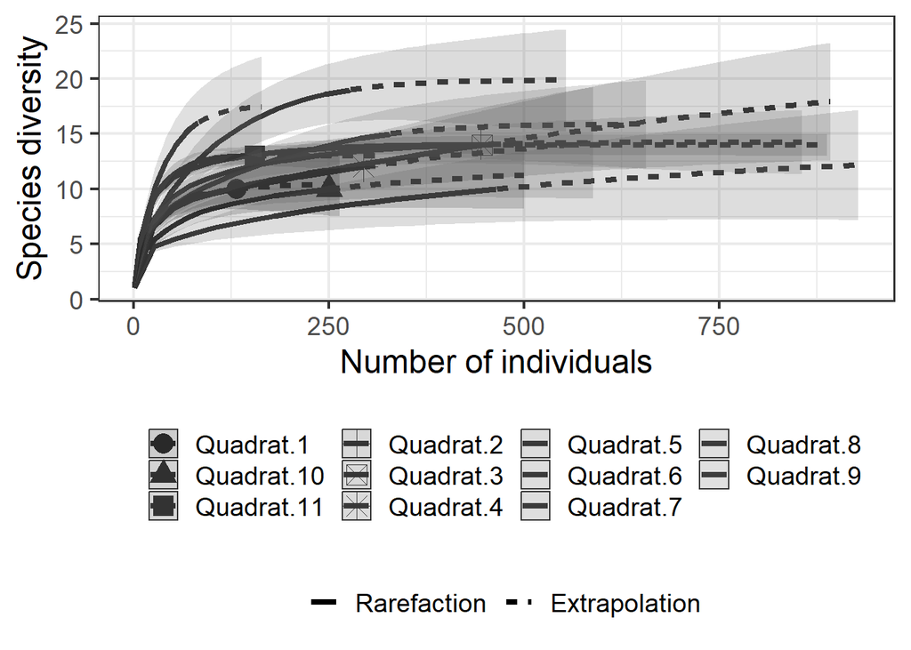

```r
Barrow_Data_Graph1 <- ggiNEXT(x = Barrow_Data, se=TRUE, type = 1,
                              facet.var = "None", grey=TRUE)
Barrow_Data_Graph1
```

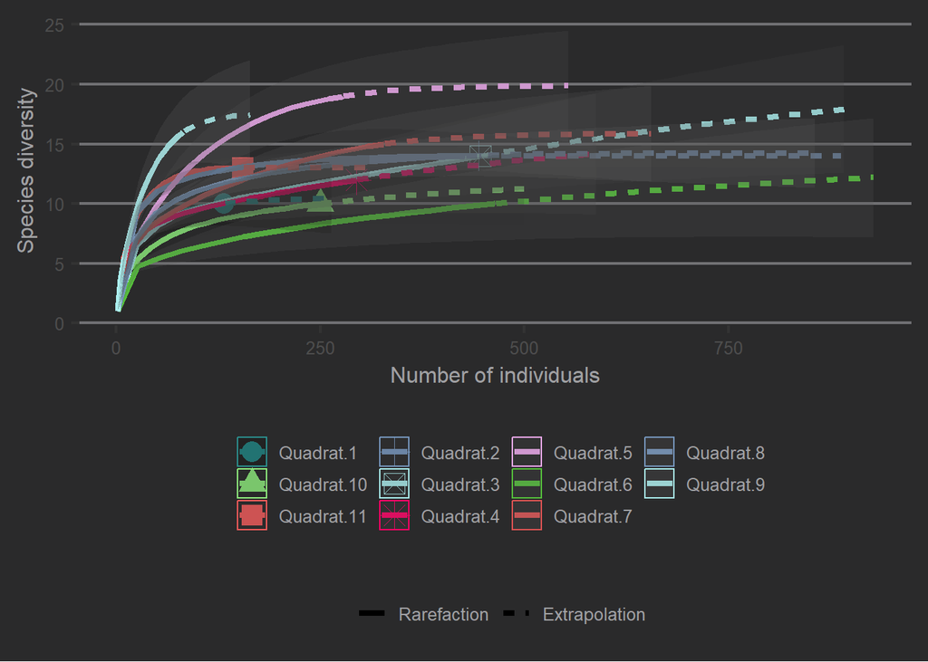

```r
g7 <- Barrow_Data_Graph1 + theme_hc(style = "darkunica") +
  scale_colour_hc("darkunica")
g7
```

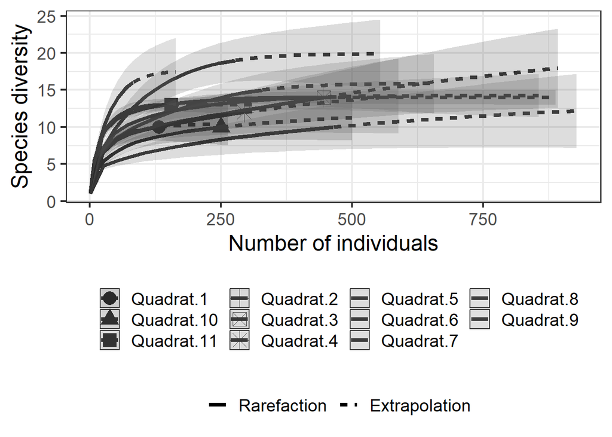

```r
Barrow_Data_Graph2 <- ggiNEXT(x = Barrow_Data, se=TRUE, type = 1,
                              facet.var="None", grey= TRUE)
Barrow_Data_Graph2
```

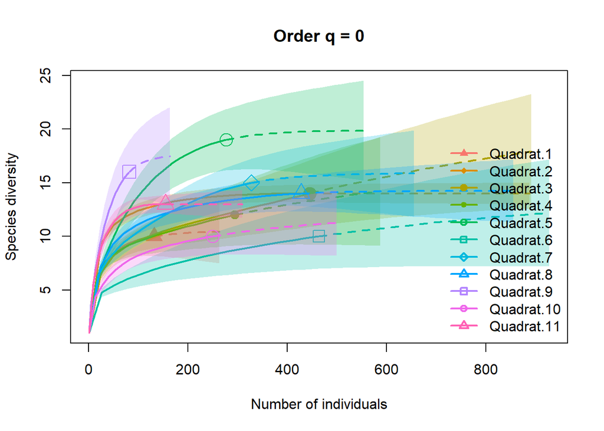

```r
plot(Barrow_Data, type=1)
```

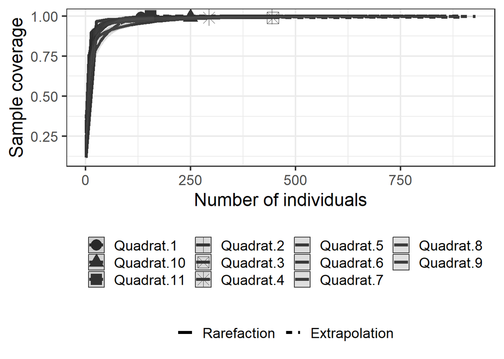

```r
Barrow_Data_Graph3 <- ggiNEXT(x = Barrow_Data, se=TRUE, type = 2,
                              facet.var="None", grey = TRUE)
Barrow_Data_Graph3
```

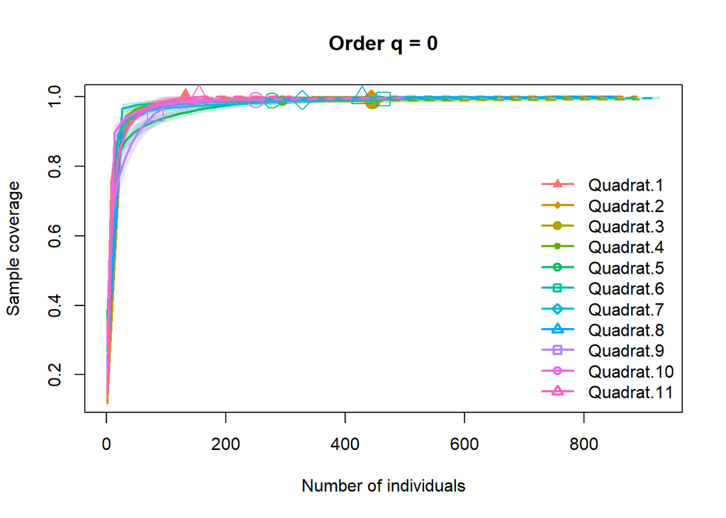

```r
plot(Barrow_Data, type=2)
```

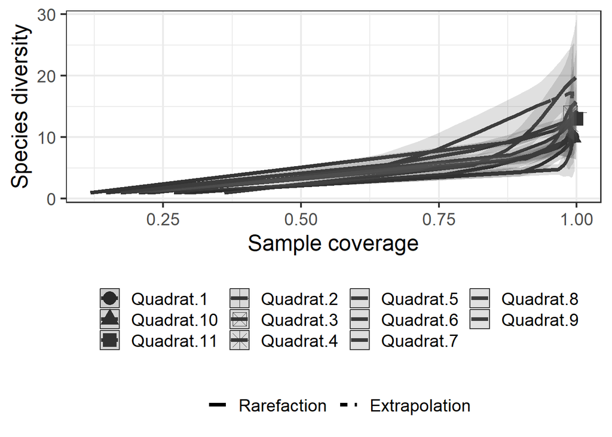

```r
Barrow_Data_Graph4 <- ggiNEXT(x = Barrow_Data, se=TRUE, type = 3,
                              facet.var="None", grey= TRUE)
Barrow_Data_Graph4
```

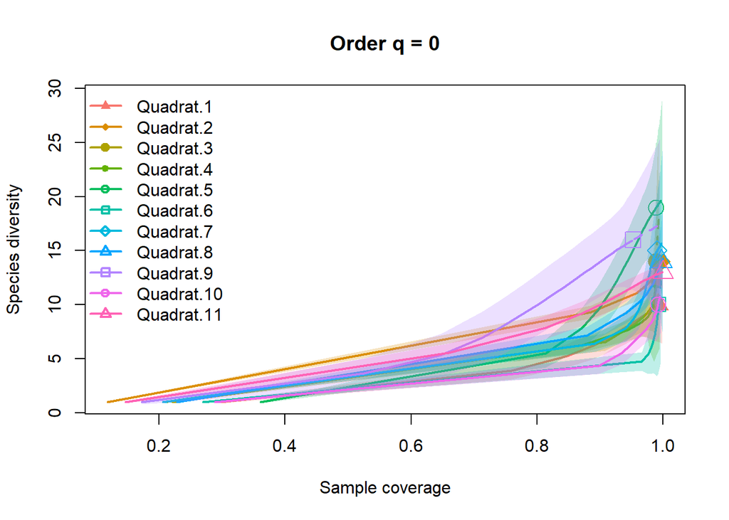

```r
plot(Barrow_Data, type=3)
```